# Why use knitR?

This is an R Markdown document, which present the basis elements to work with the knitr package in the goal to create report. Here, we presente a collection of tricks to work with knitR in R studio.

## Why use knitR?

- Generates report in HMTL, PDF, DOC
- allows the reproductibility of the result
- more easier that laTeX to produce documentation
- shortcus integrated in R studio
- combines all elements: documentation, code, result (figure, table, summaries)
- is powerful (loops, interactivity, variability of formats, …)
- uses Rmarkdown language

## Rmarkdown language.

- as HTML but without HTML tag
- R code inclusion

## Rmarkdown commands.

[figure not shown]

## Create a new Rmarkdown document.

[figure not shown]

## Include a R code in Rmarkdown document: chunk

- R code is executed in a chunk
- variables are global
- chunk could have many options (or not)

## Chunk options.

Many options are available to control the R code execution

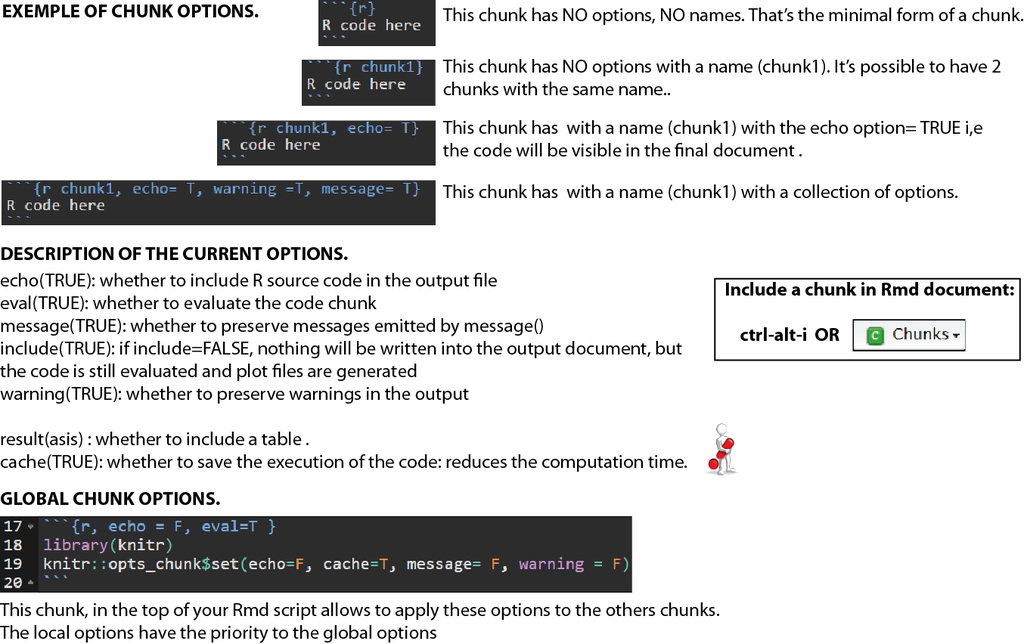

## Three ways to include a table.

### with ktable.

```r
# create a data.frame structure.
library(knitr)
mydata = data.frame(value1= 1:4, value2= 6:9)
rownames(mydata) <- paste("gene", 1:4)

kable(mydata, include.rownames=TRUE)
```

|  | value1 | value2 |
| --- | --- | --- |
| gene 1 | 1 | 6 |
| gene 2 | 2 | 7 |
| gene 3 | 3 | 8 |
| gene 4 | 4 | 9 |

### with googlevis.

```r
library(googleVis)
mydata = data.frame(value1= 1:100, value2= 6:105)
rownames(mydata) <- paste("gene", 1:100)

table = gvisTable(mydata,options=list(page='enable', height='automatic', width='automatic'))
table
```

[output not shown]

### With DT package.

```r
library(DT)

table = datatable(mydata, class = 'cell-border stripe')
table
```

[interactive table not shown]

## Include a plot in the report.

2 strategies to do that:

### from a R code directly

Here, we precise no option for the R chunk {r}

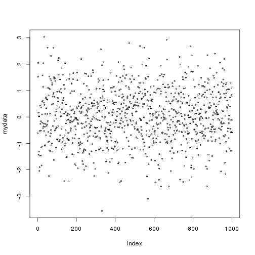

```r
mydata =rnorm(1000)
plot(mydata, cex= 0.4)
```

In this case, we precise several options in the features of the plot : {r, fig.height= 14, fig.width= 14, fig.align='center'}

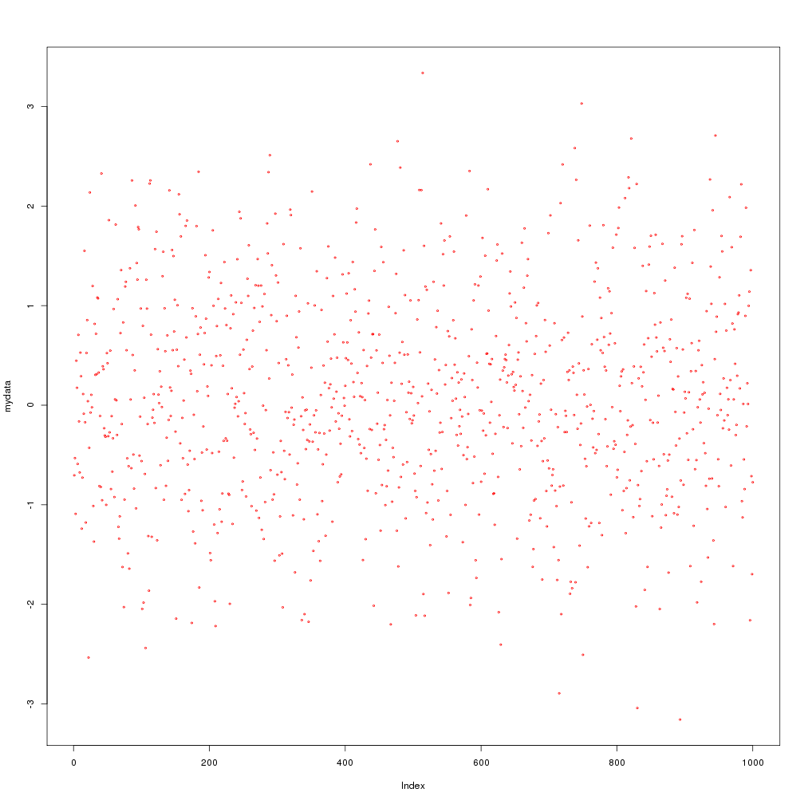

```r
mydata =rnorm(1000)
plot(mydata, cex= 0.4, col= "red")
```

### from a file

R code to generate and save the plot

```r
png("figure/plot2insert.png")
plot(mydata, cex= 0.4, col= "blue")
dev.off()
```

Include the plot with the markdown syntax.

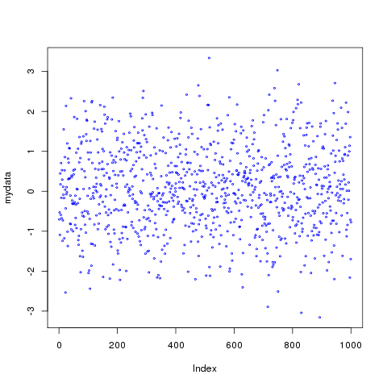

## Strategies with big Data or big Computation.

In the case, where you have a large dataset to analyze, it's important to review the way to process the data: think to process your computation on the side and save the result as a R object, which will be loaded in R chunks. Ideally, you create a R chunk with eval=F option to perform the computation: this R chunk is a component of your pipeline and is saved and available in the report ( its goal is just to generate the R objects to be visualized in the report without to be evaluated). It's a good habit to execute this part of code in Unix terminal and not in R studio server.For exemple, a function like mclapply() has a weird behaviour and batchjob usage doesn't work.

## Conclusions.

- very easy to use
- Many functions are available in R studio interface
- One document for script, documentation, result, reproducible
- allows the interactive documentation with shiny package
- allows an interactive data representation

## The next time, to go further.

- YAML header
- CSS style
- Rpres
- loops and template
- reference and bibliography
- data representation with googlevis, qtlcharts and ggbio